# Toothgrowth: An analysis of the Effect of Vitamin C in Guinea Pigs

Ian Castillo Rosales

November, 21

## About the data

The response is the length of odontoblasts (teeth) in each of 10 guinea pigs at each of three dose levels of Vitamin C (0.5, 1, and 2 mg) with each of two delivery methods (orange juice or ascorbic acid).

**The data set can be founf in the datasets package.**

We can see more tangible the structure of the data, also a summary of the three variables.

```r
head(ToothGrowth)
```

```
##    len supp dose
## 1  4.2   VC  0.5
## 2 11.5   VC  0.5
## 3  7.3   VC  0.5
## 4  5.8   VC  0.5
## 5  6.4   VC  0.5
## 6 10.0   VC  0.5
```

```r
summary(ToothGrowth)
```

```
##       len       supp         dose
##  Min.   : 4.2   OJ:30   Min.   :0.50
##  1st Qu.:13.1   VC:30   1st Qu.:0.50
##  Median :19.2           Median :1.00
##  Mean   :18.8           Mean   :1.17
##  3rd Qu.:25.3           3rd Qu.:2.00
##  Max.   :33.9           Max.   :2.00
```

Where,

```
  * len = Tooth length
  * supp = Spplement type (VC or OJ)
  * dose = Dose in milligrams
```

## Exploratory Analysis

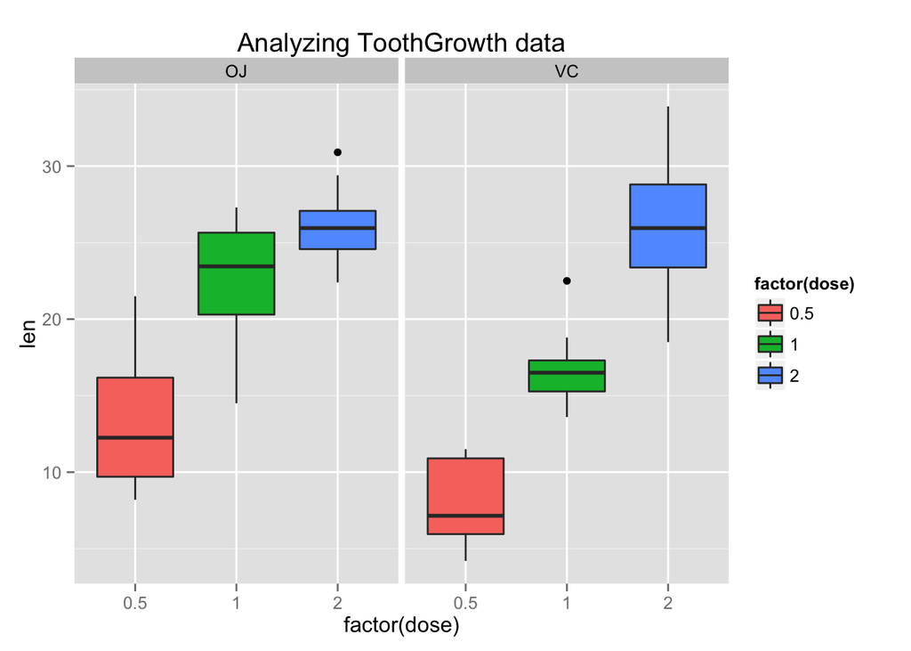

We can assume that exist some **relation between the lenght of the tooth and the dose** of the sustance, either OJ or VC. It seems that in lower doses the OJ has an better effect in the growth tooth, but in bigger doses, the effect seems to be the same.

## Data processing

We arrange the data to put the observation (pigs) versus the variables (type of supplement and dosis)

```r
vc_data <- ToothGrowth[ToothGrowth$supp == "VC",]
vc.doses <- as.data.frame(with(vc_data,split(len,dose)))
names(vc.doses) <- c("vc_0.5","vc_1","vc_2")

oj_data <- ToothGrowth[ToothGrowth$supp == "OJ",]
oj.doses <- as.data.frame(with(oj_data,split(len,dose)))
names(oj.doses) <- c("oj_0.5","oj_1","oj_2")

data <- cbind(vc.doses,oj.doses)
```

Then we execute a t-test for reject or accept our hypotesis. The results are:

```r
inters <- matrix(NA, 3, 2)
for(i in seq_along(names(vc.doses))){
      inters[i, ] <- t.test(data[, names(oj.doses)[i]] - data[, names(vc.doses)[i]], paired = F, var.equal = F)$conf
}
row.names(inters) <- c("0.5 dose", "1.0 dose", "2 dose")
colnames(inters) <- c("low.interval", "upper.interval")
```

## Conclutions

```
##          low.interval upper.interval
## 0.5 dose        1.263          9.237
## 1.0 dose        1.952          9.908
## 2 dose         -4.329          4.169
```